# Sam’s paper

Amalia MS

Monday, January 25, 2016

This document aims to reproduce the figures from Marguerat et al. 2012, but using the absolute data acquired by myself in 2014-2015. Data comes from a time course experiment done with the strain cdc2-M17as, sensitive to 1NM-PP1. When exposed to the chemical, cells arrest in G2 and grow in size until they reach a limit at around 10 hours. RNA and protein data were produced for samples taken at every hour for 11 hours of exporse to 1NM-PP1.

Quantitative mass-spectrometry was used to obtain the proteome-wide data. Samples had heavy standards spiked in, that combined with protein per cell measurements, produce copies per cell. Transcriptomics data comes from RNA-seq. calibrated to absolute copies using smFISH measurements. smFISH measurements were only taken for cells at time point zero (before the induction) for logistic reasons. RNA-seq reads were calibrated for this time point and then scaled up for the following(check absolute_rna.r)

[output not shown]

[output not shown]

# Figure 1.- Distribution of transcriptome along the time course (in log2 space).

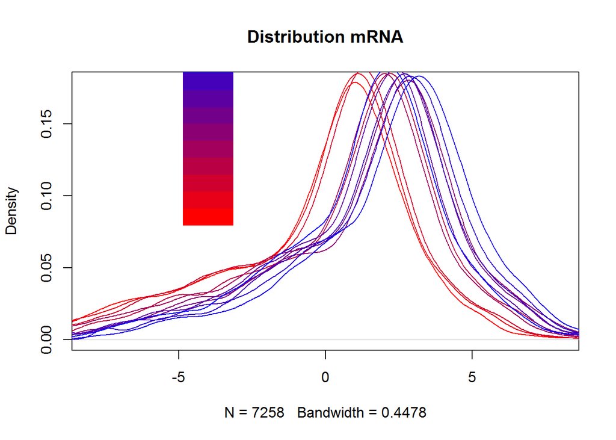

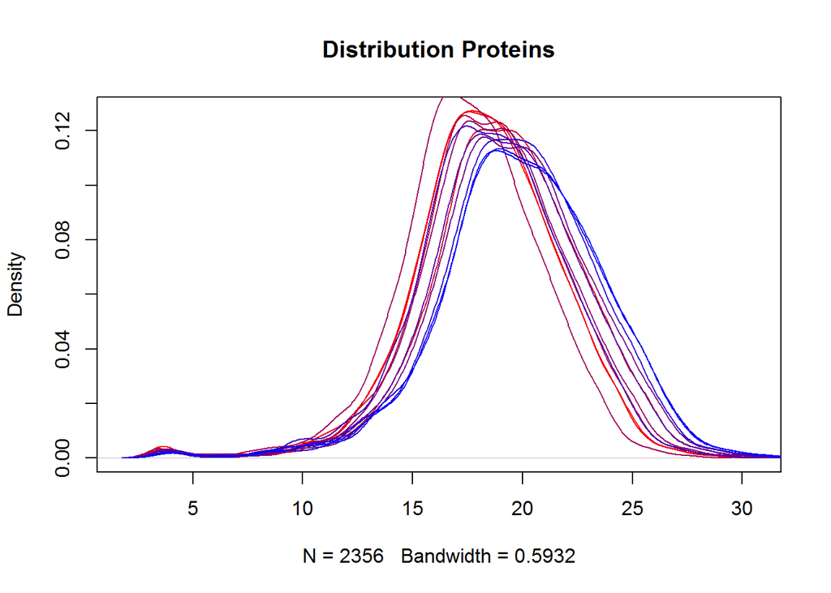

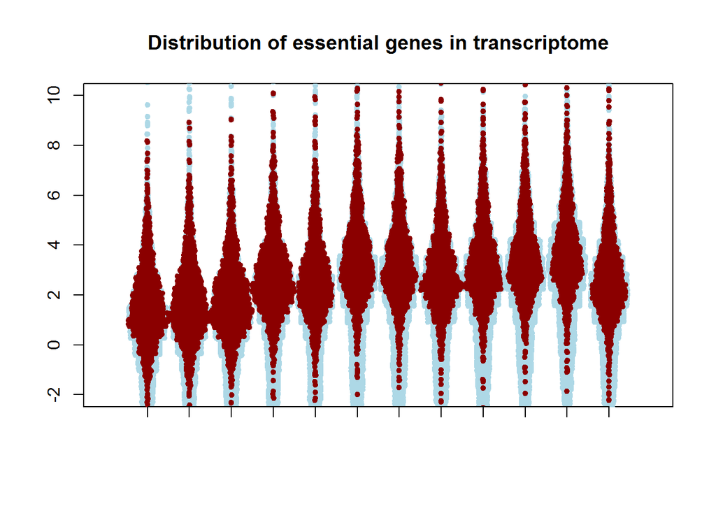

# Figure 4.- Quantitative analysis of long non conding RNAs

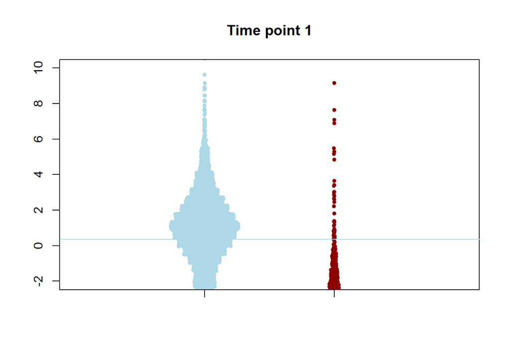

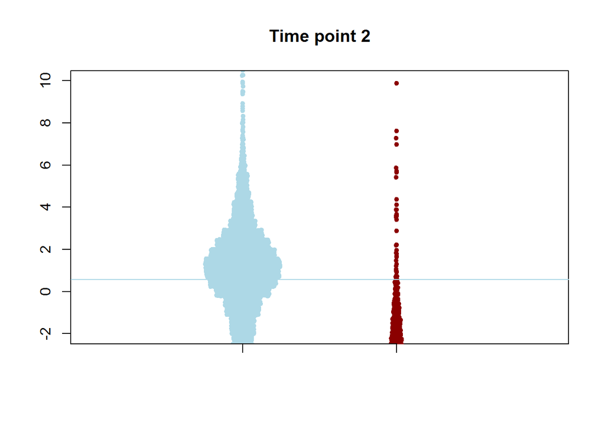

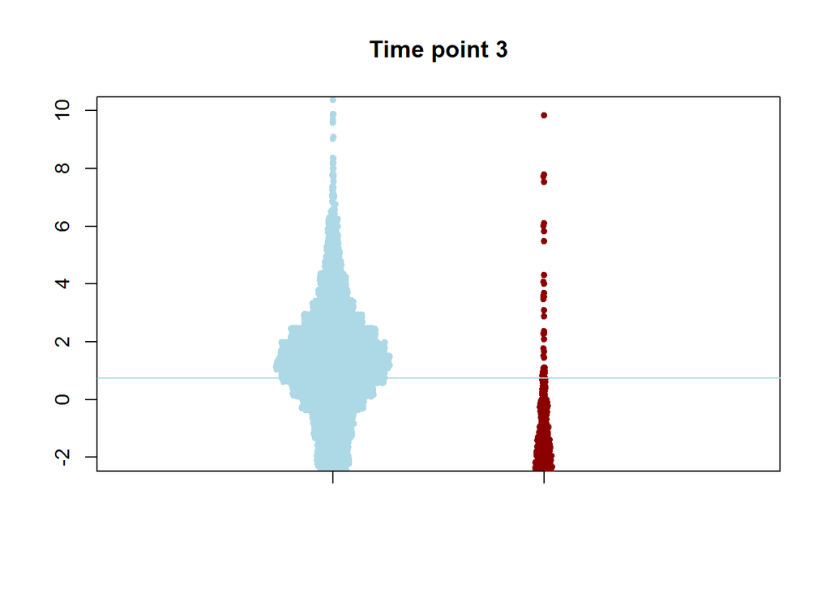

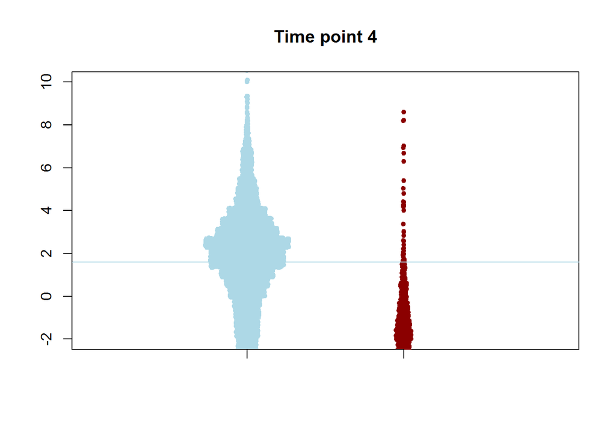

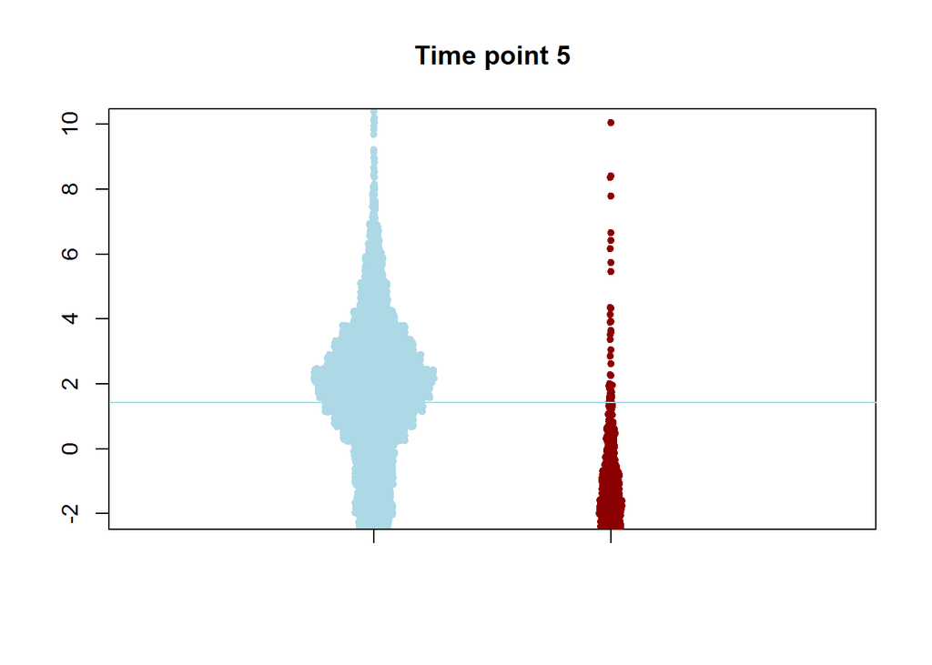

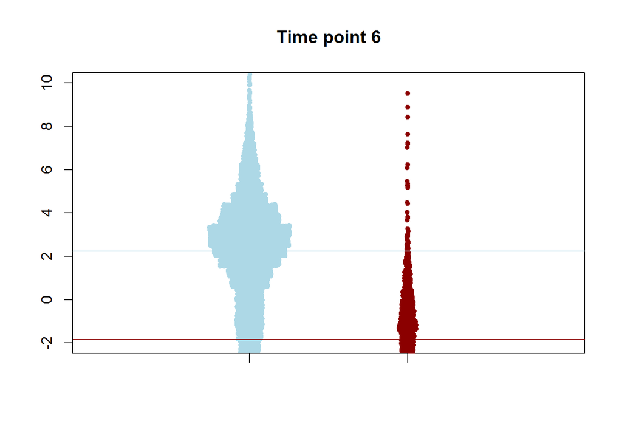

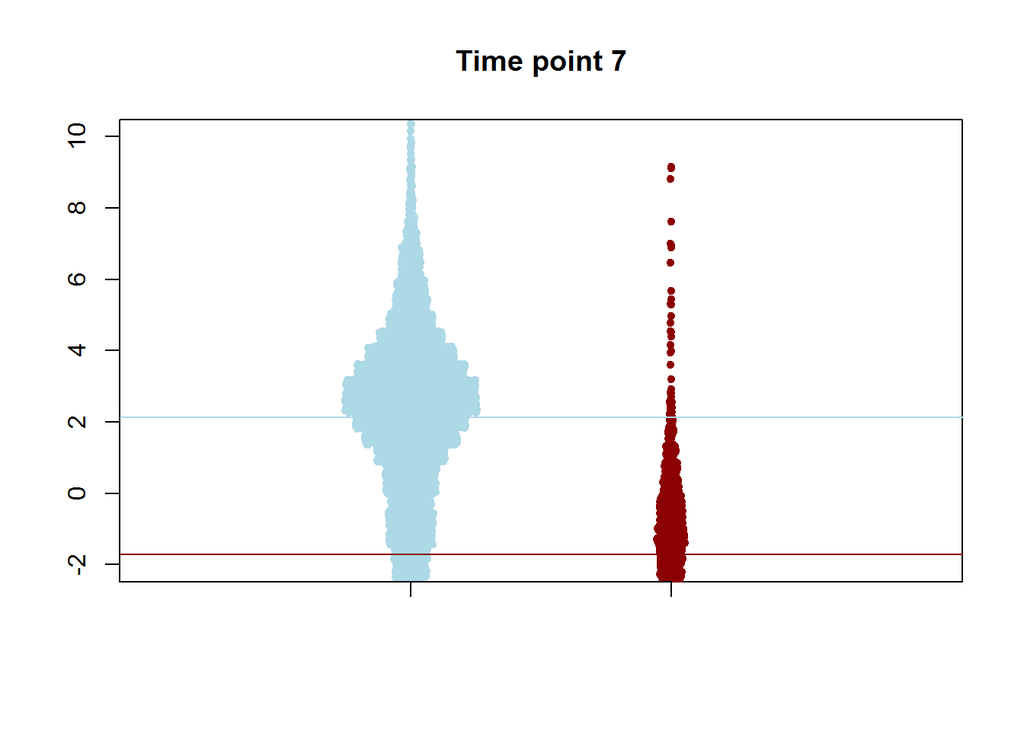

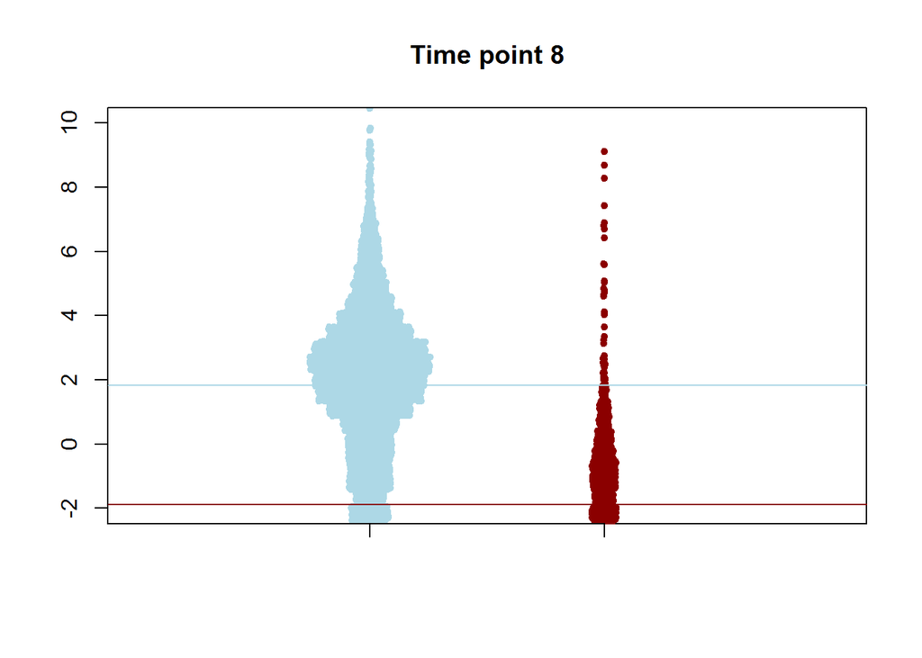

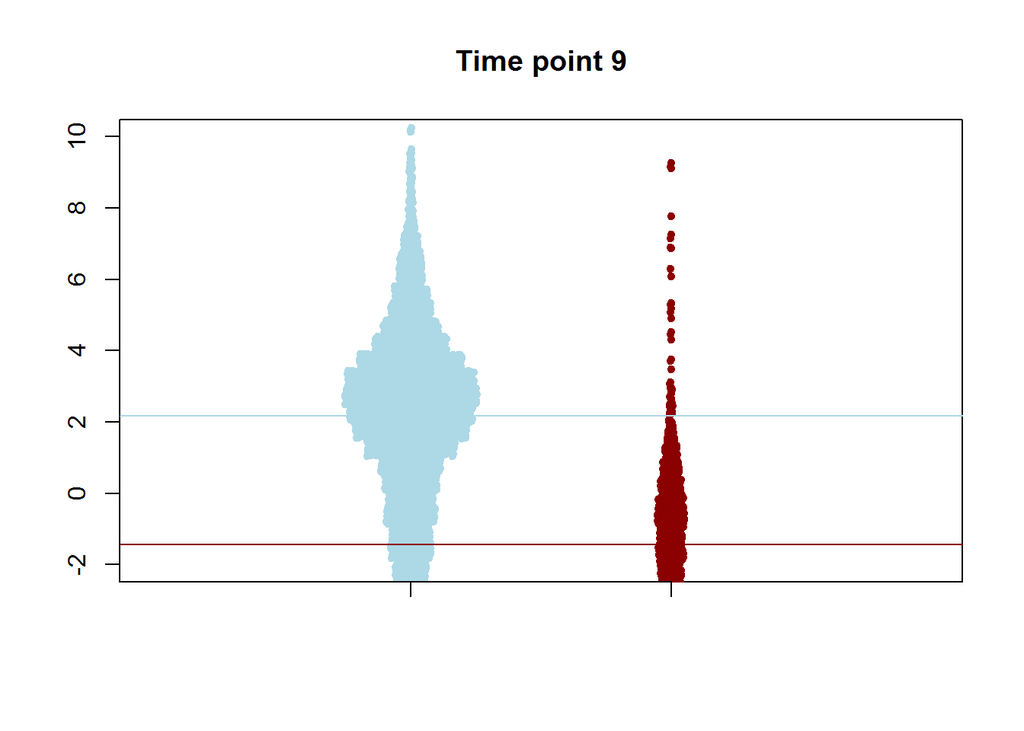

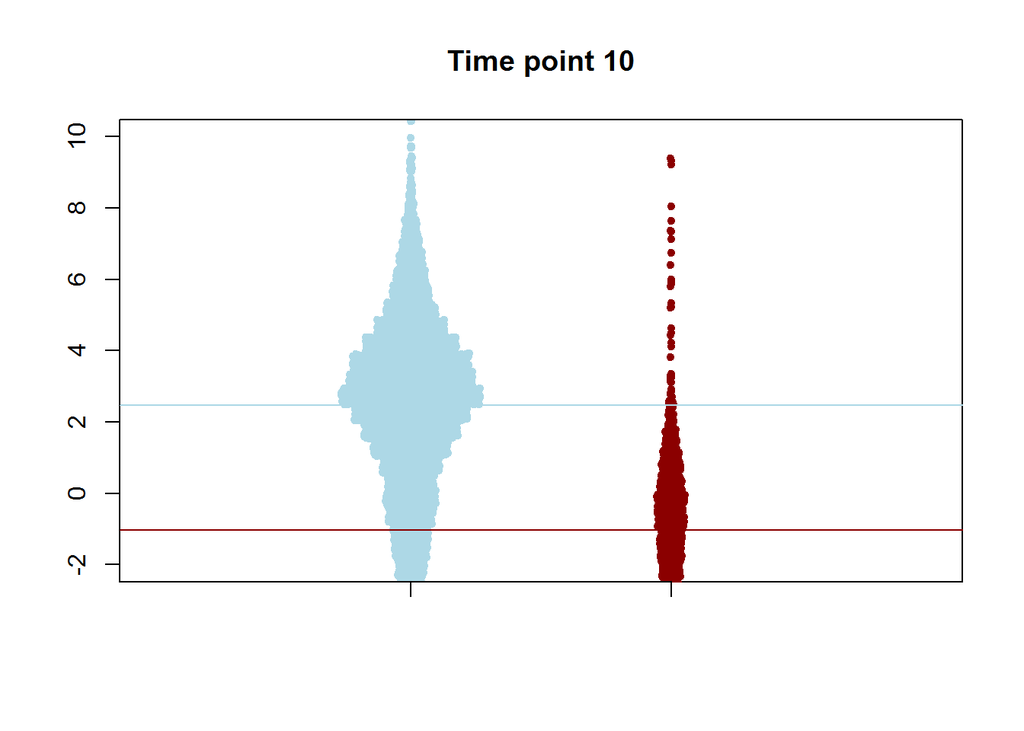

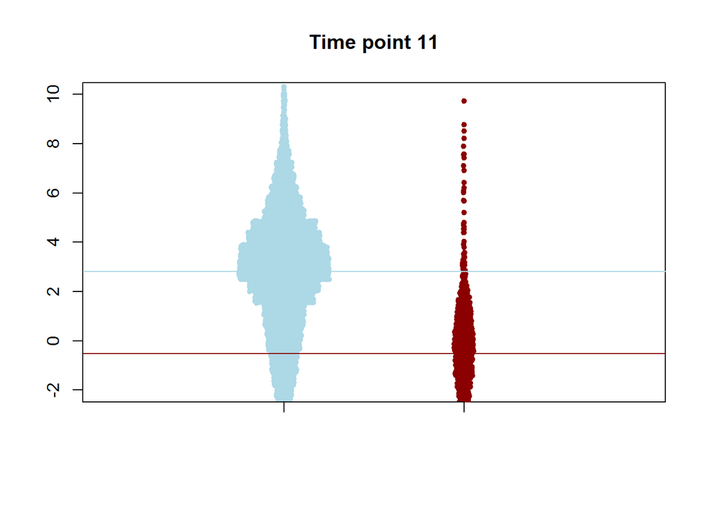

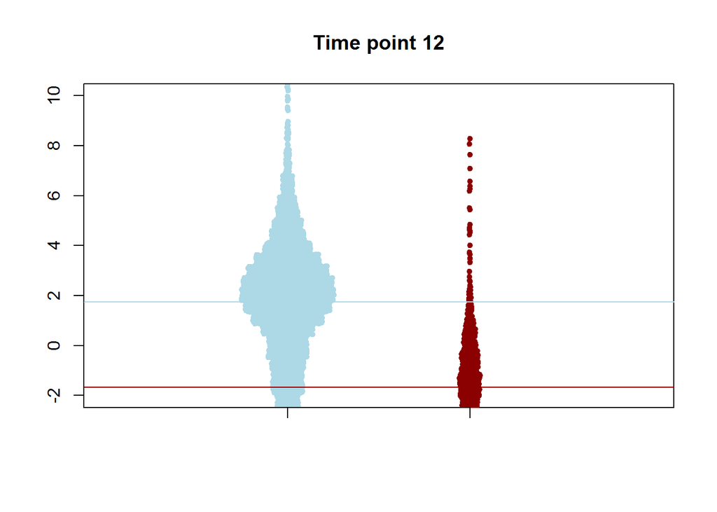

# Figure 5A .- Density plot of proteins and mRNA together

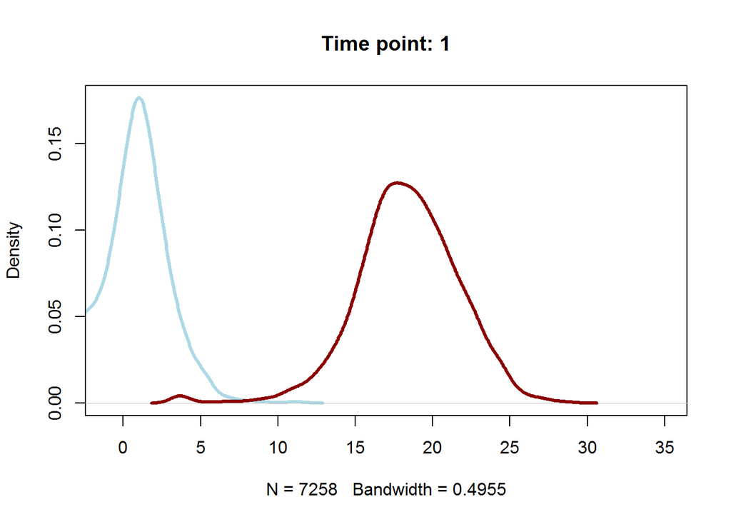

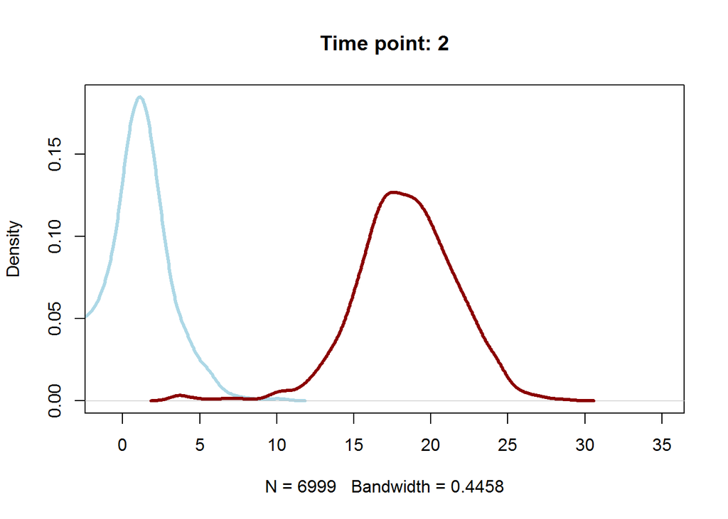

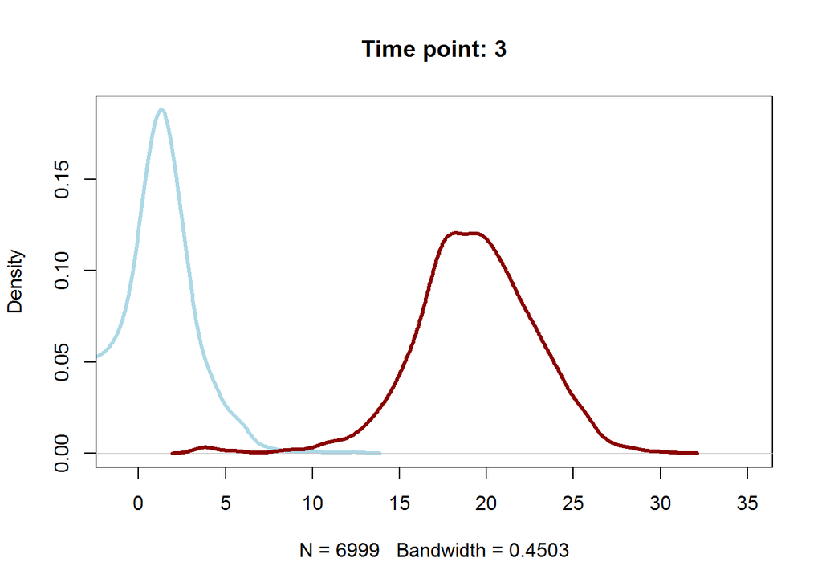

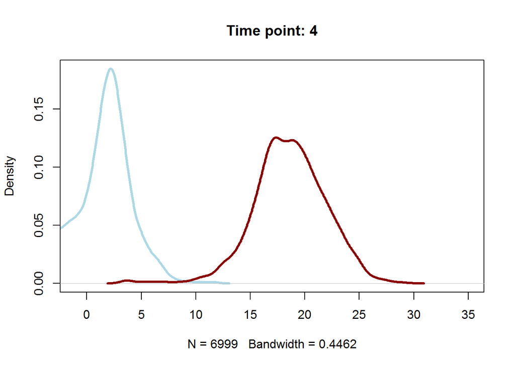

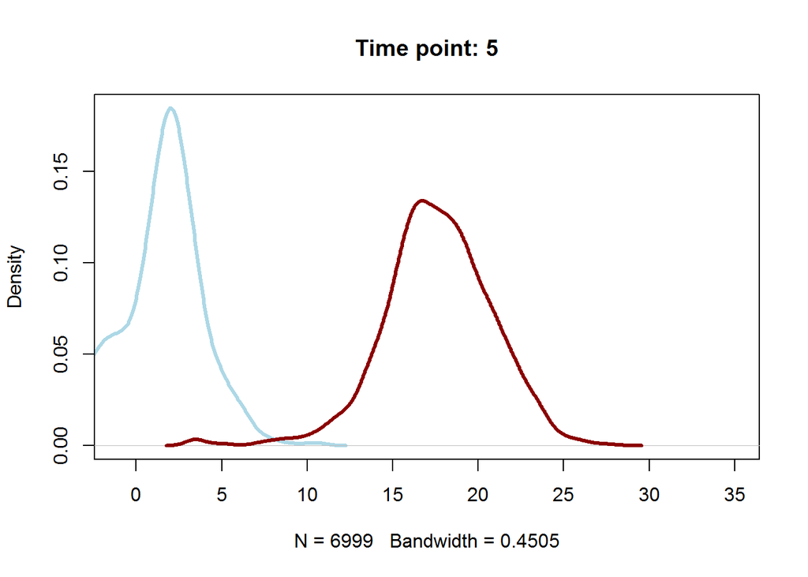

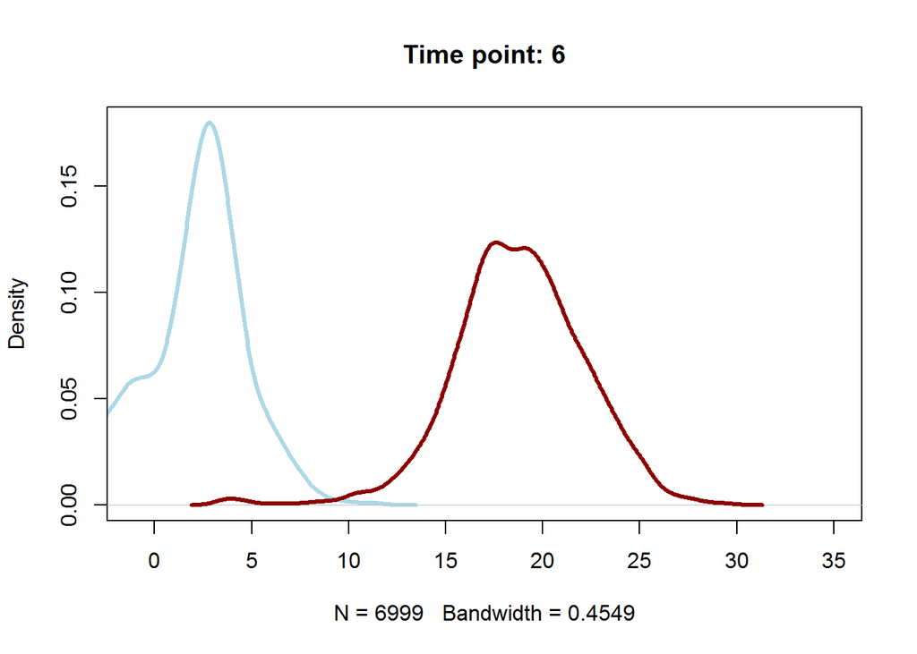

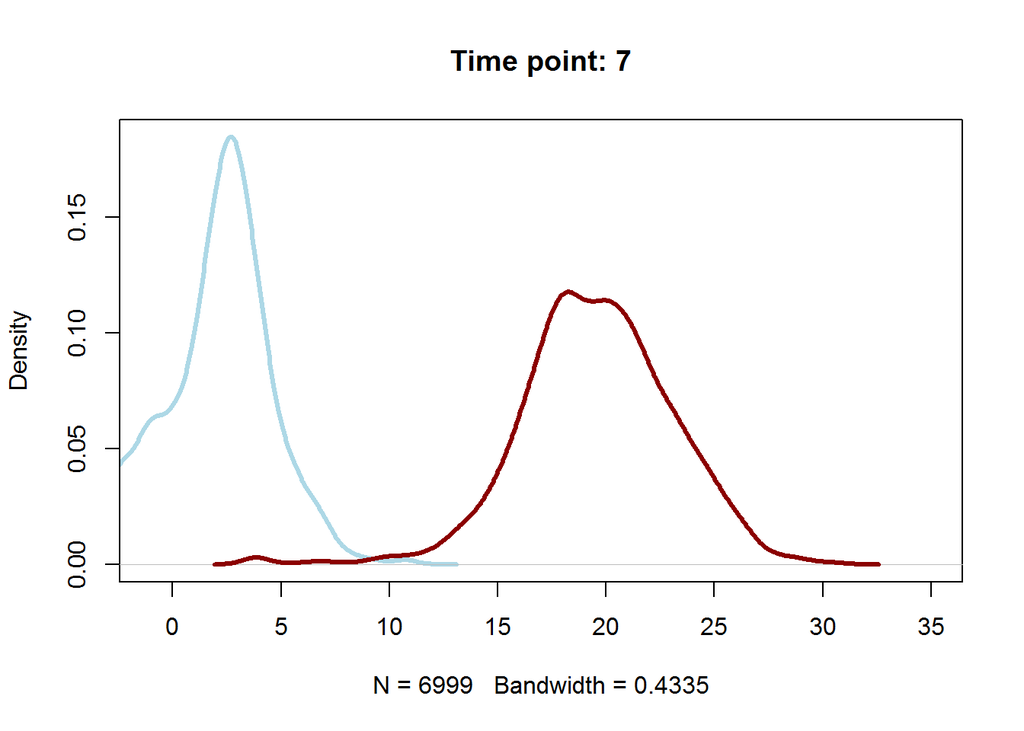

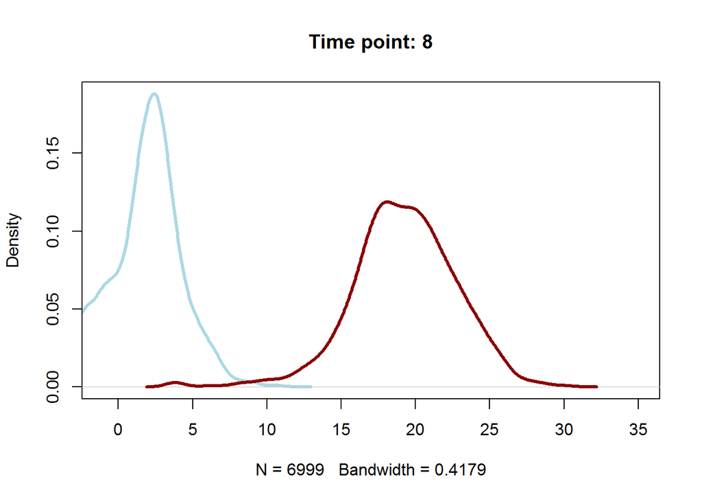

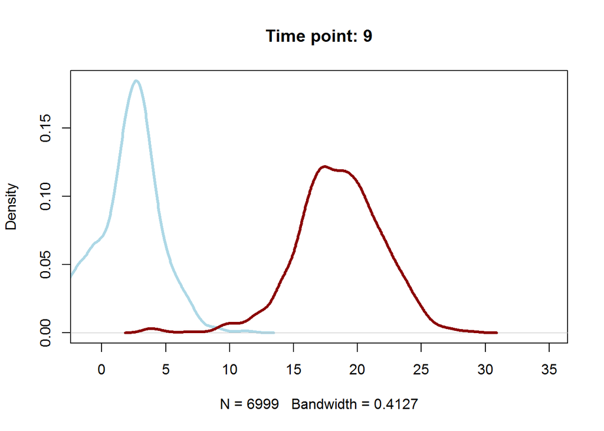

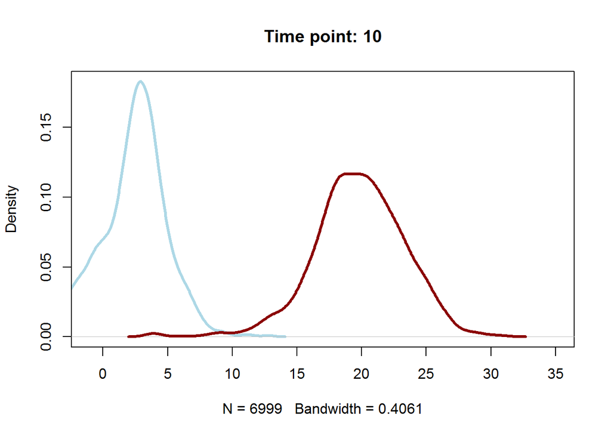

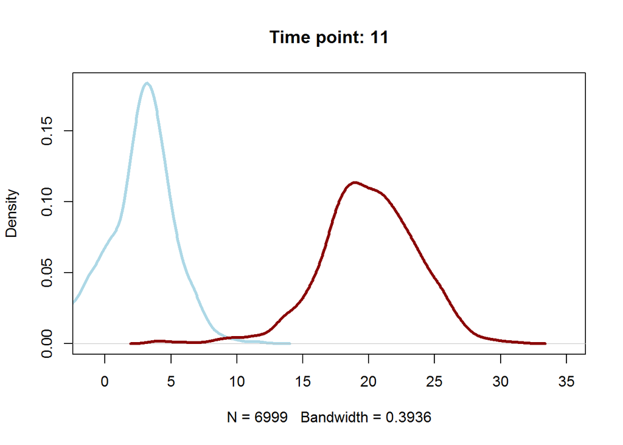

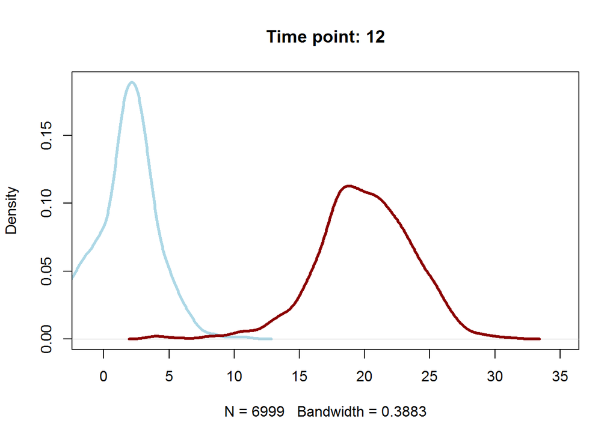

# Figure 5B.- Proteins seen in the proteome dataset are among the most expressed in the transcriptome

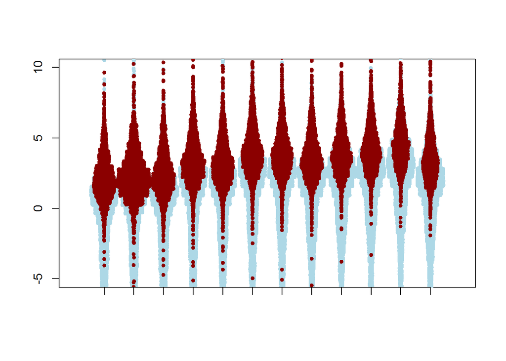

# Figure 5C.- Protein versus mRNA abundance

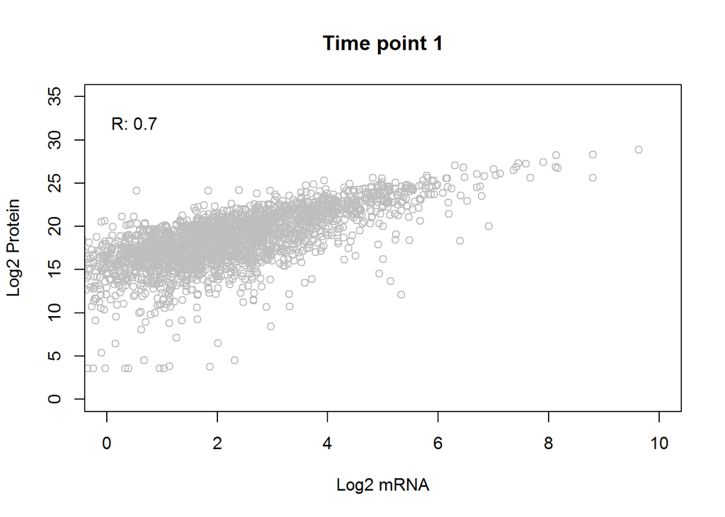

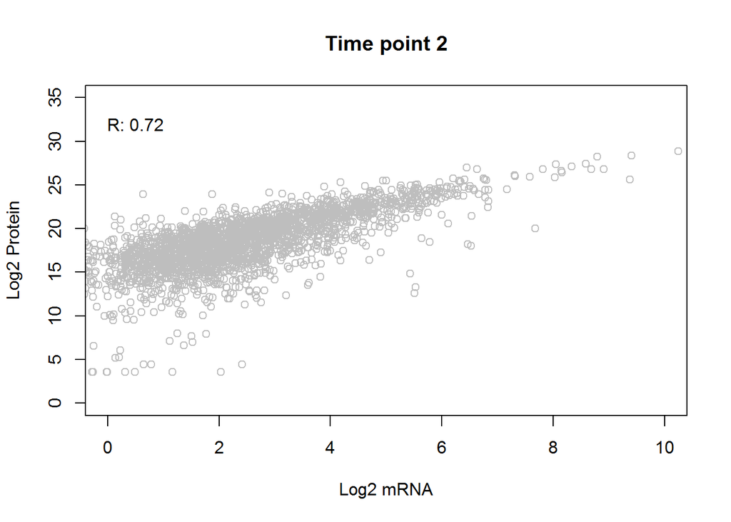

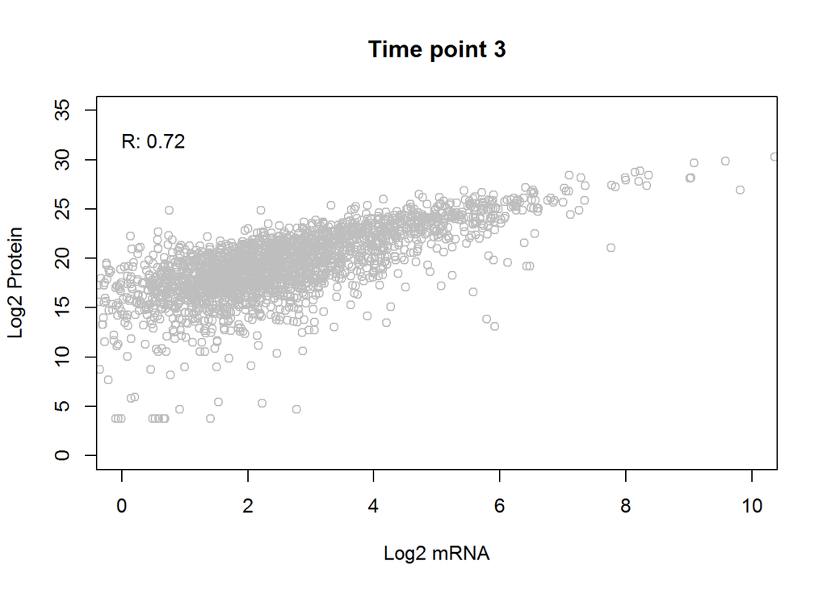

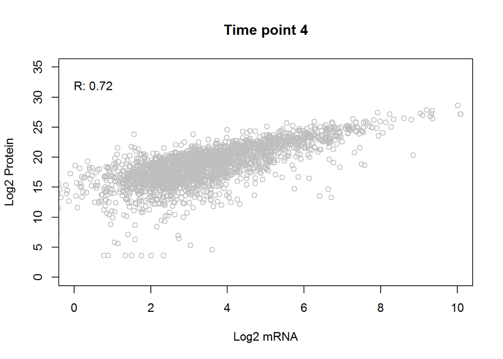